# Salamander eye size vs pupil shape

Nicole Bednarik & Katie Thomas

2023-03-20

# Data

First we import our tidied salamander morphology & trait dataset.

```r
# Import tidied salamander eye size and trait data
salamanders <- data.frame(read.csv("../Data/Tidy/salamanders_tidy.csv", header=TRUE, na.strings=c("", "NA", " ","<1")))
```

Next, we import the amphibian tree from Jetz and Pyron (2019) that has been pruned to match the salamander species in the eye size dataset.

```r
#Import pruned phylogeny
caudatatree <- read.nexus("../Data/Tidy/caudata-tree.nex")
```

Then we find species averages for salamander eye size

```r
# species means for cornea data
av.sal <- salamanders %>%
  mutate_if(is.character, as.factor) %>%
  group_by(Genus_Species) %>%
  summarise(eye_av = mean(eyemean),
            cor_av = mean(cormean),
            svl_av = mean(SVL_mm),
            rootmass_av = mean(rootmass),
            n = n())
```

Next, we import the salamander pupil categorization data and tidy it.

```r
#Import amphibian pupil data
pupils_raw <- data.frame(read.csv("../Data/Raw/salamander_pupils.csv", header=TRUE, na.strings=c("", "NA")))

#Tidy dataset to remove ambiguous species & unneeded columns
pupils <- pupils_raw %>%
  #remove rows marked to be excluded
  filter(Final_Constriction != "(exclude?)" & Final_Constriction != "(exclude)" & Final_Constriction != "(maybe exclude?)") %>%
  #recode horizontal with space after to match other horizontal
  mutate(Pupil_constriction = recode(Final_Constriction, "horizontal " = "horizontal")) %>%
  #rename shape column
  mutate(Pupil_shape = Final_Shape) %>%
  #get rid of unneeded columns
  select(Genus_Species, Pupil_source, Pupil_constriction, Pupil_shape)

#export tidied pupil data
write.csv(pupils, file = "../Data/Tidy/pupils_tidy.csv")
```

Finally, we merge the pupil data with the eye size data.

```r
#Add pupil data to salamander data
sal <- merge(av.sal, pupils, by="Genus_Species", all.x = FALSE, all.y = FALSE) %>% droplevels()
```

# Analysis

Next, we use PGLS to test for a correlation between pupil constriction (horizontal or symmetrical) and cornea size across species.

First we match the data to the tree in caper. Note that this is dropping the “Pleurodes waltl gilled” specimen (we have measurements from a non-gilled specimen which is being used here, but both have symmetrical circular pupils, though different eye sizes).

```r
#Make row names of dataset the species names (so it will match phylogeny tips)
rownames(sal) <- sal$Genus_Species

#check that names match in dataframe and tree
name.check(phy = caudatatree, data = sal)
```

```
## $tree_not_data
##  [1] "Aneides_flavipunctatus"     "Aneides_niger"
##  [3] "Batrachoseps_relictus"      "Batrachuperus_karlschmidti"
##  [5] "Batrachuperus_yenyuanensis" "Bolitoglossa_marmorea"
##  [7] "Bolitoglossa_morio"         "Cynops_wolterstorffi"
##  [9] "Eurycea_rathbuni"           "Hynobius_amjiensis"
## [11] "Hynobius_sonani"            "Plethodon_dunni"
##
## $data_not_tree
## [1] "Pleurodeles_waltl_gilled"
```

```r
#use caper function to combine phylogeny and data into one object (this function also matches species names in tree and dataset)
sal.comp <- comparative.data(phy = caudatatree, data = sal,
                            names.col = Genus_Species, vcv = TRUE,
                            na.omit = FALSE, warn.dropped = TRUE)
```

Then we fit the PGLS model.

```r
#elongated pupils vs. eye diameter
pgls_pupil.eye <- pgls(cor_av ~ Pupil_constriction,
               data = sal.comp,
               lambda = "ML",
               param.CI = 0.95)
```

We need to check that model assumptions are being met.

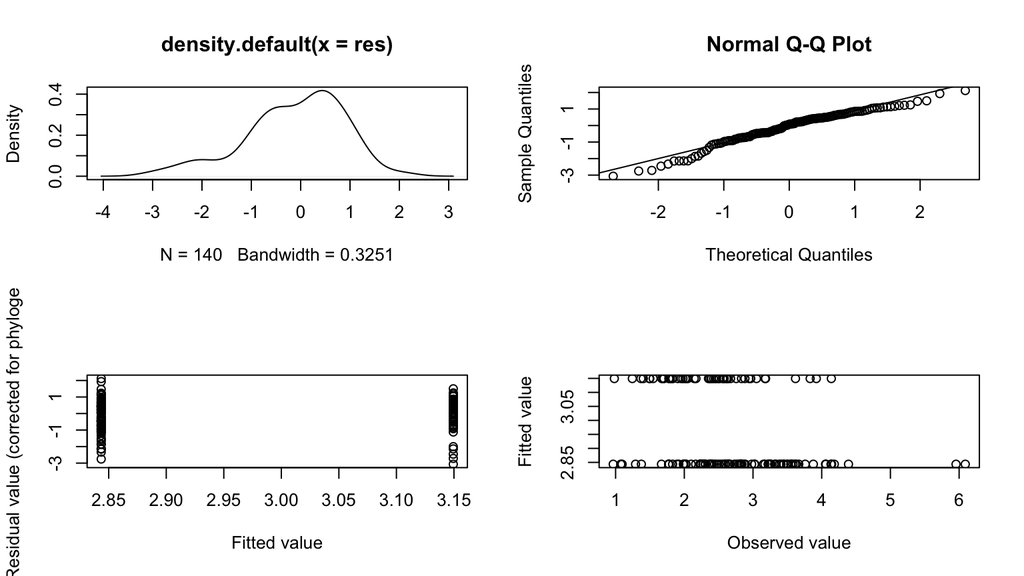

```r
#evaluate model assumptions
par(mfrow = c(2,2)) #makes your plot window into 2x2 panels
plot(pgls_pupil.eye) #plot the linear model
```

```r
par(mfrow = c(1,1)) #set plotting window back to one plot
```

These look ok. Next we look at the model parameter estimates.

```r
#main effects
anova(pgls_pupil.eye)
```

```
## Analysis of Variance Table
## Sequential SS for pgls: lambda = 0.81, delta = 1.00, kappa = 1.00
##
## Response: cor_av
##                     Df  Sum Sq   Mean Sq F value Pr(>F)
## Pupil_constriction   1 0.01547 0.0154670  2.6196 0.1078
## Residuals          138 0.81481 0.0059044
```

```r
#parameter estimates
summary(pgls_pupil.eye)
```

```
##
## Call:
## pgls(formula = cor_av ~ Pupil_constriction, data = sal.comp,
##     lambda = "ML", param.CI = 0.95)
##
## Residuals:
##       Min        1Q    Median        3Q       Max
## -0.233169 -0.054703  0.005758  0.044175  0.161003
##
## Branch length transformations:
##
## kappa  [Fix]  : 1.000
## lambda [ ML]  : 0.813
##    lower bound : 0.000, p = 2.9343e-12
##    upper bound : 1.000, p = < 2.22e-16
##    95.0% CI   : (0.637, 0.914)
## delta  [Fix]  : 1.000
##
## Coefficients:
##                               Estimate Std. Error t value  Pr(>|t|)
## (Intercept)                    3.14942    0.43316  7.2709 2.419e-11 ***
## Pupil_constrictionsymmetrical -0.30595    0.18903 -1.6185    0.1078
## ---
## Signif. codes:  0 '***' 0.001 '**' 0.01 '*' 0.05 '.' 0.1 ' ' 1
##
## Residual standard error: 0.07684 on 138 degrees of freedom
## Multiple R-squared: 0.01863, Adjusted R-squared: 0.01152
## F-statistic:  2.62 on 1 and 138 DF,  p-value: 0.1078
```

There is no significant difference in cornea diameter in species with horizontal vs. symmetrical constricting pupils.

# Visualization

Here, we can visualize these data using a boxplot.

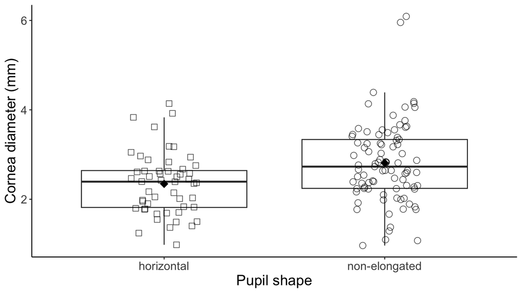

```r
#shapes for boxplots
sh_constrict <- c("horizontal" = 22,
                   "symmetrical" = 21)


#plot absolute cornea size vs. pupil shape
boxplot_eyesize <- ggplot(data = sal,
                       aes(x = Pupil_constriction, y = cor_av)) +
  geom_boxplot(notch = FALSE, outlier.shape = NA, alpha = 0.9) + #controls boxes
   geom_jitter(aes(shape = Pupil_constriction), size = 3, alpha = 0.7, position = position_jitter(0.15)) +
  scale_x_discrete(limits = c("horizontal", "symmetrical"),
                   labels = c("horizontal", "non-elongated")) +
  stat_summary(fun.x = mean, colour = "black", geom = "point", shape = 18, size = 4, show_guide = FALSE) + #controls what stats shown
  scale_shape_manual(values = sh_constrict,
                     name = "",
                     breaks = c("horizontal", "symmetrical"),
                     labels = c("horizontal", "non-elongated")) +
  theme(text = element_text(size=16), panel.background = element_blank(), axis.line = element_line(colour = "black"), legend.position="none") + #controls background
  xlab("Pupil shape") +
  ylab("Cornea diameter (mm)")

#show figure
boxplot_eyesize
```